# NLSY79 longitudinal project

Author

Cristian T

Published

August 5, 2024

```r
suppressMessages(library(tidyverse))
suppressMessages(library(tibble))
suppressMessages(library(dplyr))
suppressMessages(library(ggplot2))
suppressMessages(library(scales))
suppressMessages(library(RColorBrewer))

# Read the RData files into a data frame
load("physical_data_nlsy79.RData")
load("education_data_nlsy79.RData")
load("income_data_nlsy79.RData")
```

## Join Data

Our analysis examines income, education, and physical characteristics in 2014, so we joined the relevant datasets and restricted the year.

```r
data <- inner_join(income_data_nlsy79, education_data_nlsy79,
                  by=c("CASEID", "year"))
data <- inner_join(data, physical_data_nlsy79,
                  by=c("CASEID", "year")) %>%
  select(CASEID, year, income, education, hair, sex)
data <- data %>% filter(year==2014)
glimpse(data)
```

```
Rows: 12,686
Columns: 6
$ CASEID    <int> 1, 2, 3, 4, 5, 6, 7, 8, 9, 10, 11, 12, 13, 14, 15, 16, 17, 1…
$ year      <int> 2014, 2014, 2014, 2014, 2014, 2014, 2014, 2014, 2014, 2014, …
$ income    <int> NA, 21000, 40000, NA, NA, 112000, NA, 47000, 80000, NA, NA, …
$ education <int> NA, 12, 10, NA, NA, 16, NA, 14, 14, NA, NA, NA, NA, 18, 16, …
$ hair      <chr> NA, "light brown", "blond", "light brown", NA, "brown", "bro…
$ sex       <chr> "female", "female", "female", "female", "male", "male", "mal…
```

After joining and limiting the year to 2014, the filtered data has 12686 rows and six columns.

## Exploration of the Income Variable

We will begin by running some basic summary statistics to provide us with a basic understanding of the distribution and characteristics of the income data in the dataset. We first run a check for missing values to assess data completeness. We further explore the measures of central tendency (mean, median), dispersion (standard deviation), and range (minimum and maximum values).

```r
# Check for missing values in the income column
missing_incomes <- sum(is.na(data$income))
# Mean
mean_income <- mean(data$income, na.rm = TRUE)
# Median
median_income <- median(data$income, na.rm = TRUE)
# Standard deviation
sd_income <- sd(data$income, na.rm = TRUE)
# Minimum
min_income <-min(data$income, na.rm = TRUE)
# Maximum
max_income <- max_income <- max(data$income, na.rm = TRUE)
# Printing the results
cat("\nMissing Incomes:", missing_incomes, "\n")
```

```
Missing Incomes: 5903
```

```r
cat("\nMean Income:", mean_income, "\n")
```

```
Mean Income: 42403.01
```

```r
cat("Median Income:", median_income, "\n")
```

```
Median Income: 28000
```

```r
cat("Standard Deviation of Income:", sd_income, "\n")
```

```
Standard Deviation of Income: 60847.59
```

```r
cat("Minimum Income:", min_income, "\n")
```

```
Minimum Income: 0
```

```r
cat("Maximum Income:", max_income, "\n")
```

```
Maximum Income: 370314
```

```r
#overview of Summary statistics
summary(income_data_nlsy79$income)
```

```
   Min. 1st Qu.  Median    Mean 3rd Qu.    Max.    NA's
      0    1344   12000   19867   26000  370314   85628
```

Visually inspecting income we see the following plot.

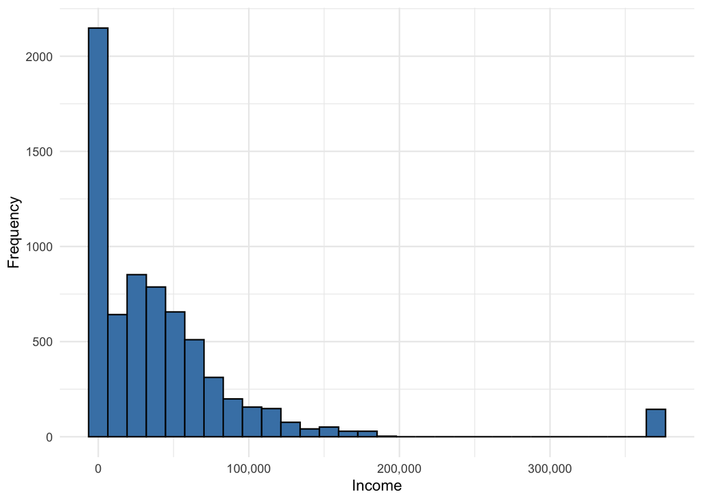

```r
p <- ggplot(data, aes(x = income)) +
  geom_histogram(bins = 30, fill = "steelblue", color = "black") +  # Specify fill and border color
  labs(x = "Income", y = "Frequency") +
  scale_x_continuous(labels = scales::comma) +
  theme_minimal()

ggsave("income.png", plot = p)
p
```

Based on the above graph, over 2000 responses show zero income in 2014, but we will keep our zero values. We want to explore the level of education and how it correlates with income.

Remove any rows with missing values in income.

```r
data <- data %>%
  filter(!is.na(income))
```

## Study of Education

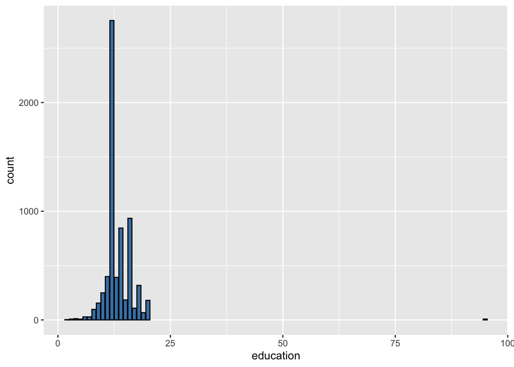

```r
p <- ggplot(data = data, aes(x = education)) + geom_bar(fill = "steelblue", color = "black")
ggsave("education.png", plot = p)
p
```

This plot reveals the spurious value 95, meaning some ungraded education. We’ll exclude these from the analysis. Evidently, there are few of these values in the education data.

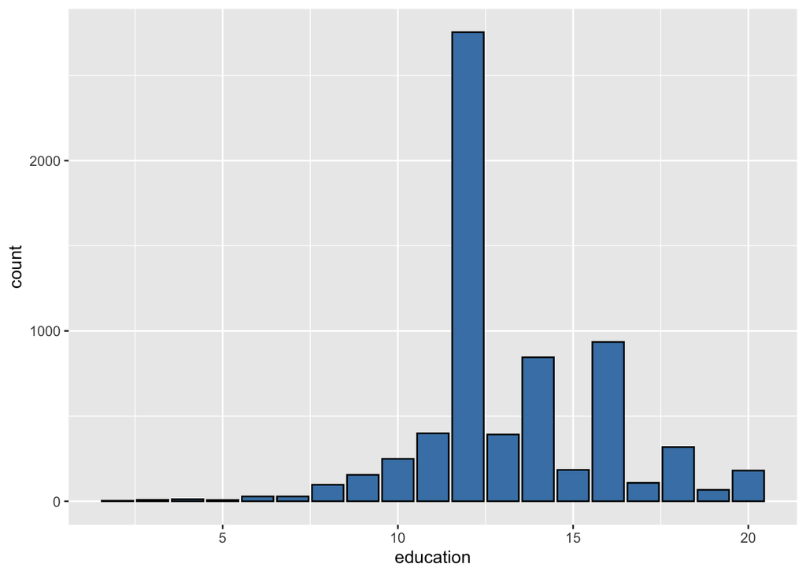

```r
p <- ggplot(
  data = filter(data, education < 95),
  aes(x = education)
) + geom_bar(fill = "steelblue", color = "black")
ggsave("education.png", plot = p)
p
```

```r
data <- data %>% filter(education<95)
```

```r
sum(is.na(data$education))
```

```
[1] 0
```

There is no missing value in education now.

## Study of Gender

Let’s plot sex to examine the distribution.

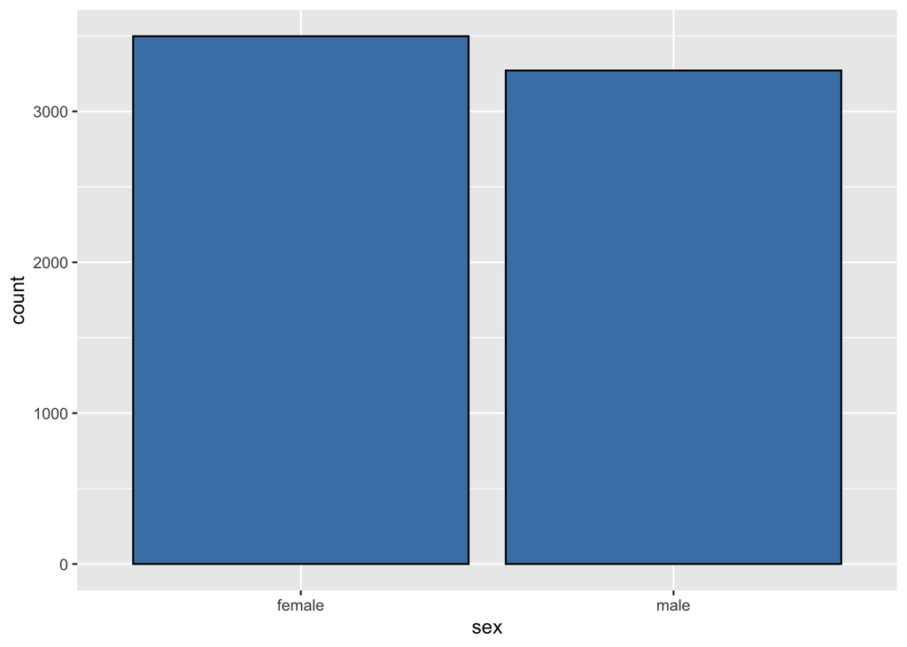

```r
p <- ggplot(data = data, aes(x = sex)) + geom_bar(fill = "steelblue", color = "black")
ggsave("sex.png", plot = p)
p
```

```r
sum(is.na(data$sex))
```

```
[1] 0
```

There is no missing value in sex now.

## Study of Hair

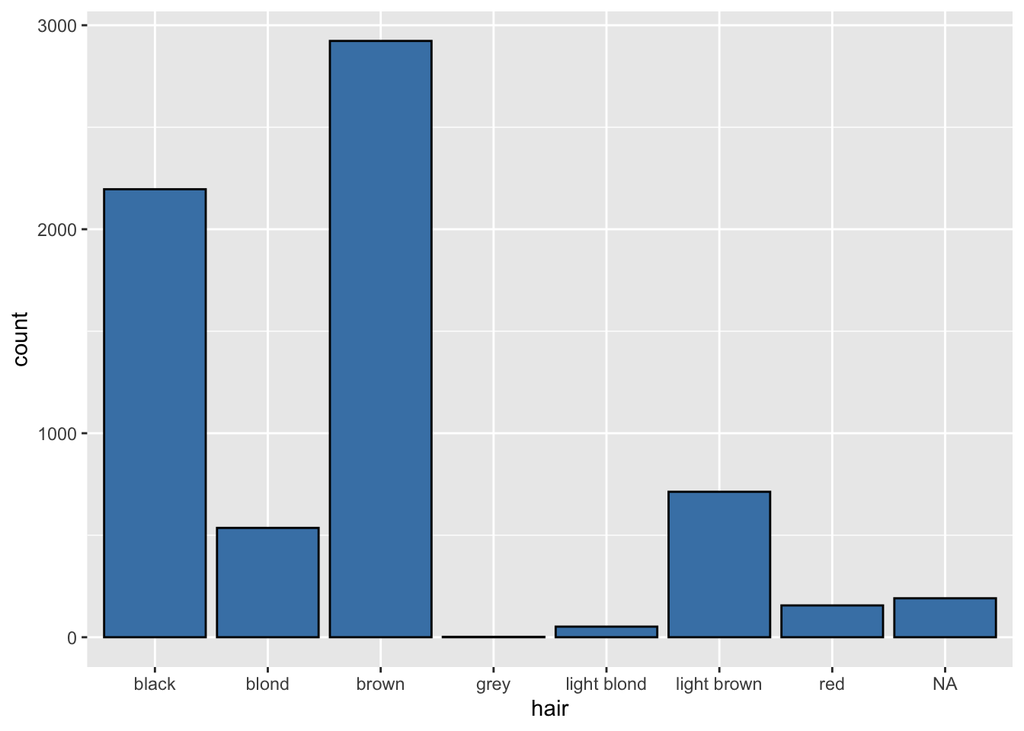

```r
p <- ggplot(data = data,  aes(x = hair) ) + geom_bar(fill = "steelblue", color = "black")
ggsave("hair.png", plot = p)
p
```

This graph shows that over 2,500 respondents have brown hair, and over 2,000 respondents have black hair.

```r
sum(is.na(data$hair))
```

```
[1] 191
```

There are 191 missing values in hair.

## Explore the Effects of Education on Income

In this section, we are looking at the connection between education levels and income. We are trying to understand income distribution dynamics concerning different educational milestones and the individuals’ mean income.

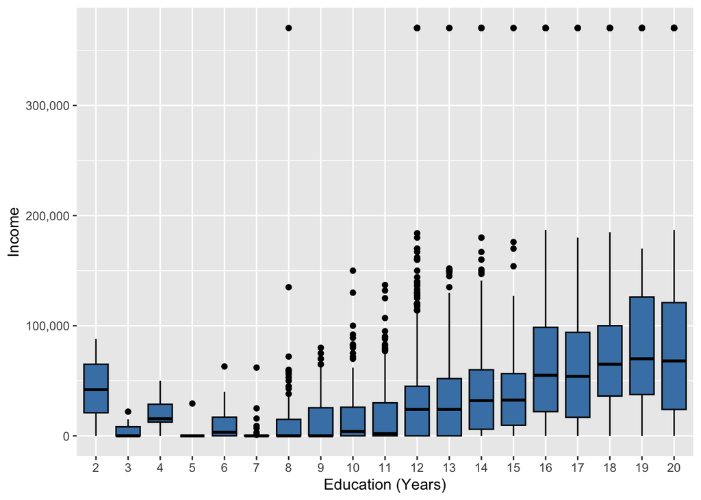

```r
#plot showing distribution education and income
p <- ggplot(data, aes(x = as.factor(education), y = income)) +
  geom_boxplot(fill = "steelblue", color = "black") +
  labs(x = "Education (Years)", y = "Income") +
  scale_y_continuous(labels = scales::comma)
ggsave("income_education.png", plot = p)
p
```

In the above graph, we are exploring the relationship between education levels and income. The chart presents a box plot showing income distribution across various education levels, using blue boxes to highlight the interquartile range of incomes within each group. The plot suggests that there is a positive association between income and years of education.

To further clean things up, we will exclude any education under the 8th grade. We are performing this cleanse to comply with inaccuracies and following the law that most states have some compulsory education laws and adjusting for potential age allowances that some states will allow one to drop out of school.

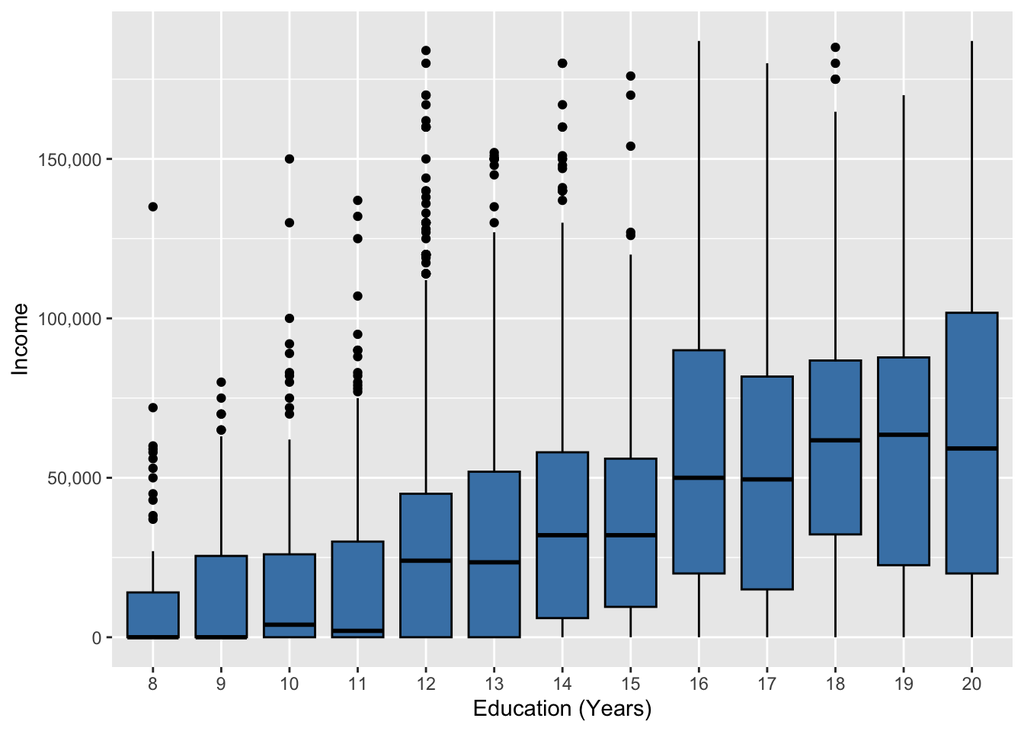

```r
p <- ggplot(
  filter(data, education >= 8  & income <= 200000),
  aes(x = as.factor(education), y = income)) +
  geom_boxplot(fill = "steelblue", color = "black") +
  labs(x = "Education (Years)", y = "Income") +
  scale_y_continuous(labels = scales::comma)
ggsave("income_education_yrs.png", plot = p)
p
```

The positive linear relationship becomes more evident after removing the respondents with less than eight years of education, highlighting the influence of education level on income.

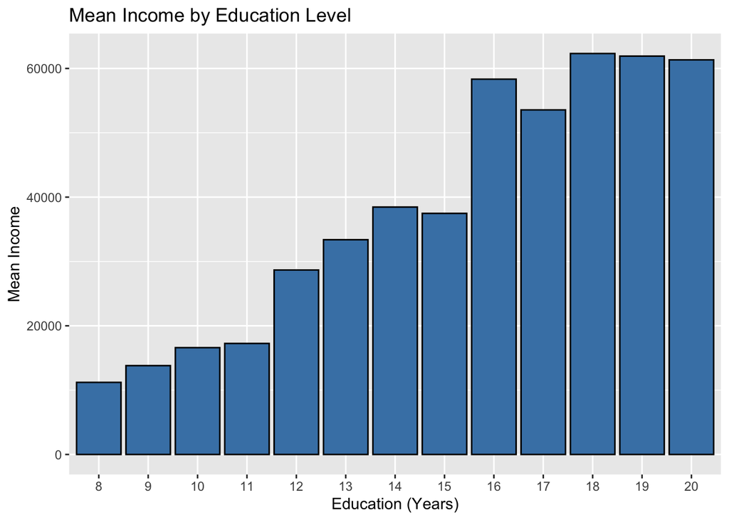

```r
income_by_education_mean <- data %>%
  filter(income <= 200000, education >= 8) %>%
  group_by(education) %>%
  summarize(mean_income = mean(income, na.rm = TRUE))

p <- ggplot(income_by_education_mean,
       aes(x = as.factor(education), y = mean_income)) +
  geom_bar(stat = "identity", fill = "steelblue", color = "black") +
  labs(x = "Education (Years)", y = "Mean Income", title = "Mean Income by Education Level")
ggsave("mean_income_by_years.png", plot = p)
p
```

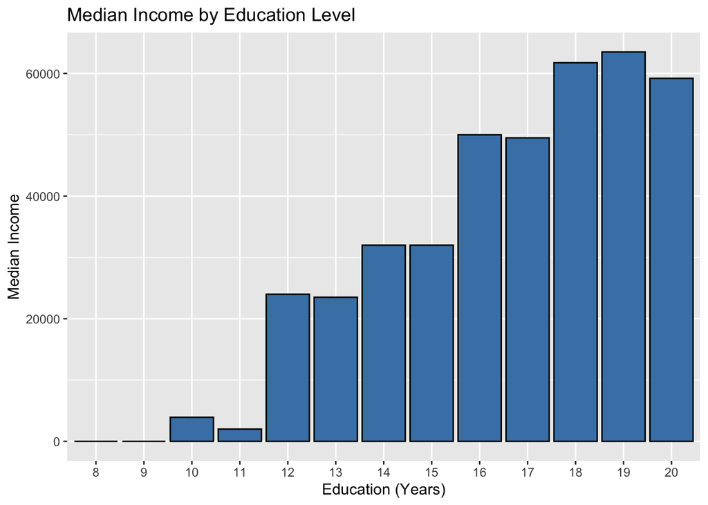

```r
income_by_education_median <- data %>%
  filter(income <= 200000, education >= 8) %>%
  group_by(education) %>%
  summarize(median_income = median(income, na.rm = TRUE))

p <- ggplot(income_by_education_median, aes(x = as.factor(education), y = median_income)) +
  geom_bar(stat = "identity", fill = "steelblue", color = "black") +
  labs(x = "Education (Years)", y = "Median Income", title = "Median Income by Education Level")
ggsave("mean_income_by_level.png", plot = p)
p
```

Continuing our examination, we look at the relationship between education levels and income by summarizing individuals’ mean and median income better to understand the income distribution within each education group. The bar chart illustrates how mean and median income differs across these academic years. Looking at both of the graphs, we see how much those exceptionally high incomes have affected the overall mean income, while the median incomes appears to be reflective of the majority of individuals.

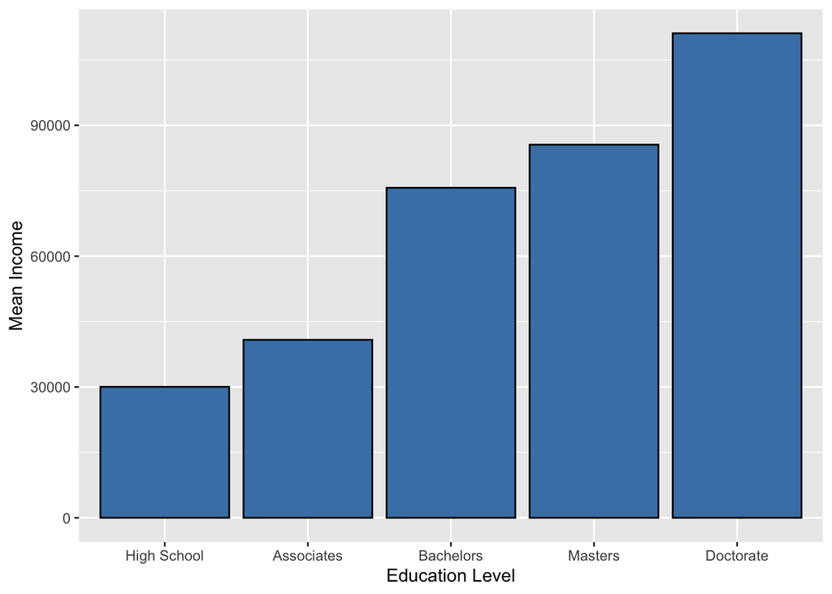

```r
# Filter the data for the specific education levels
education_levels <- c(12, 14, 16, 18, 20)
income_by_education <- data %>%
  filter(education %in% education_levels)

# Create a bar plot for mean
p <- ggplot(income_by_education, aes(x = factor(education), y = income)) +
  geom_bar(stat = "summary", fun = "mean", fill = "steelblue", color = "black") +
  labs(x = "Education Level", y = "Mean Income") +
  scale_x_discrete(labels = c("12" = "High School", "14" = "Associates", "16" = "Bachelors", "18" = "Masters", "20" = "Doctorate"))
ggsave("mean_income_by_education.png", plot = p)
p
```

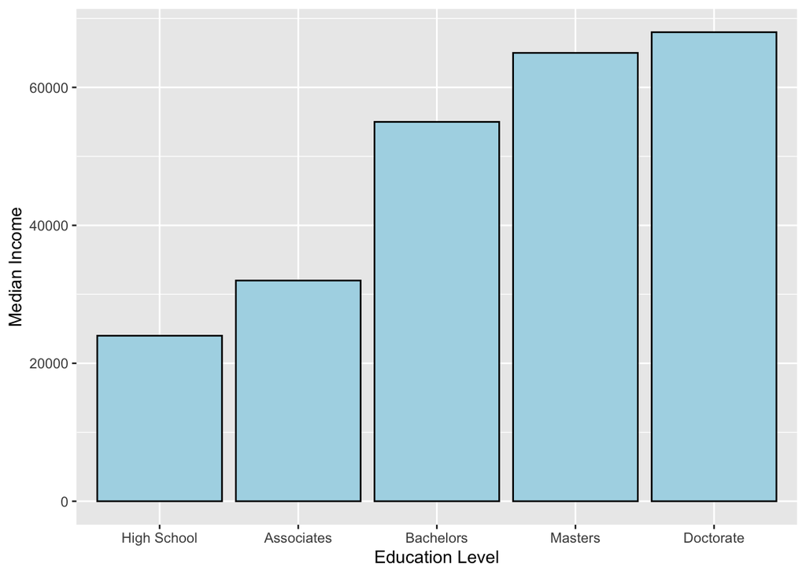

```r
# Create a bar plot for median
q <- ggplot(income_by_education, aes(x = factor(education), y = income)) +
  geom_bar(stat = "summary", fun = "median", fill = "lightblue", color = "black") +
  labs(x = "Education Level", y = "Median Income") +
  scale_x_discrete(labels = c("12" = "High School", "14" = "Associates", "16" = "Bachelors", "18" = "Masters", "20" = "Doctorate"))
ggsave("mean_income_by_education.png", plot = q)
q
```

This second series of graphs focuses on specific education levels (12, 14, 16, 18, 20) corresponding to milestones such as high school, associate’s degrees, bachelor’s degrees, MBAs, and doctorates. We calculate and visualize the mean and median income for individuals with these distinct education levels.

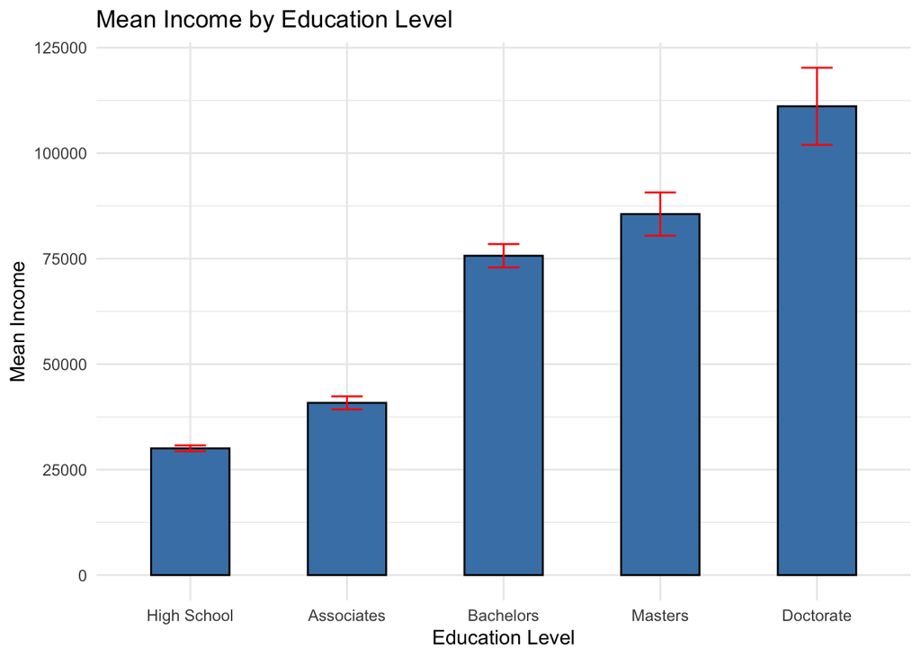

```r
# Calculate summary statistics for income by education level
summary_stats <- income_by_education %>%
  group_by(education) %>%
  summarise(mean_income = mean(income, na.rm = TRUE),
            sd_income = sd(income, na.rm = TRUE),
            n = n())

# Create a bar plot with error bars
p <- ggplot(summary_stats, aes(x = factor(education), y = mean_income)) +
  geom_bar(stat = "identity", fill = "steelblue", color = "black", width = 0.5) +
  geom_errorbar(aes(ymin = mean_income - sd_income / sqrt(n), ymax = mean_income + sd_income / sqrt(n)),
                width = 0.2, color = "red") +
  labs(x = "Education Level", y = "Mean Income", title = "Mean Income by Education Level") +
  scale_x_discrete(labels = c("12" = "High School", "14" = "Associates", "16" = "Bachelors", "18" = "Masters", "20" = "Doctorate")) +
  theme_minimal()
ggsave("mean_income_by_education_level.png", plot = p)
p
```

We are looking at the mean income for each education level achieved in 2014. This graph shows the average income for individuals with each corresponding education level. We added the red error bars to provide insights into the reliability of these income estimates, showing us the variability in income within each education level and representing the uncertainty or variability in the average income estimates for each education level. The height of these bars reflects the degree of variability within each education level’s income, with taller bars signifying greater variability and shorter bars indicating less uncertainty in the income estimate